# Part 1: Using R as a Research Tool

### Adding a statistical test with `stat_smooth()`

The function `stat_smooth()` is built to “aid the eye in seeing patterns” in your data. Let’s have a go by adding it as a new layer in our plot:

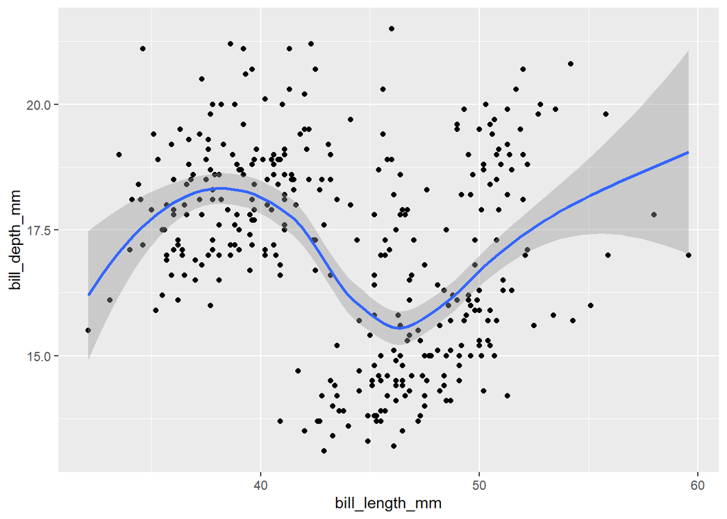

```r
ggplot(penguins, aes(x = bill_length_mm, y = bill_depth_mm)) +
  geom_point() +
  stat_smooth()
```

The default of this function is to do what is called a “loess” smoothing, a type of moving regression. Sometimes this is useful, but in our case it is *not* useful. We need to specify that we want to use a linear regression.

We know that calling a linear regression can be done with `lm()`, which gives the intercept and slope:

```r
lm(bill_depth_mm ~ bill_length_mm, data = penguins)
```

```
##
## Call:
## lm(formula = bill_depth_mm ~ bill_length_mm, data = penguins)
##
## Coefficients:
##    (Intercept)  bill_length_mm
##       20.88547        -0.08502
```

We can add a linear regression to our graph by specifying that we want to use `lm()` as our smooth function. We do this with `stat_smooth(method = "lm")`:

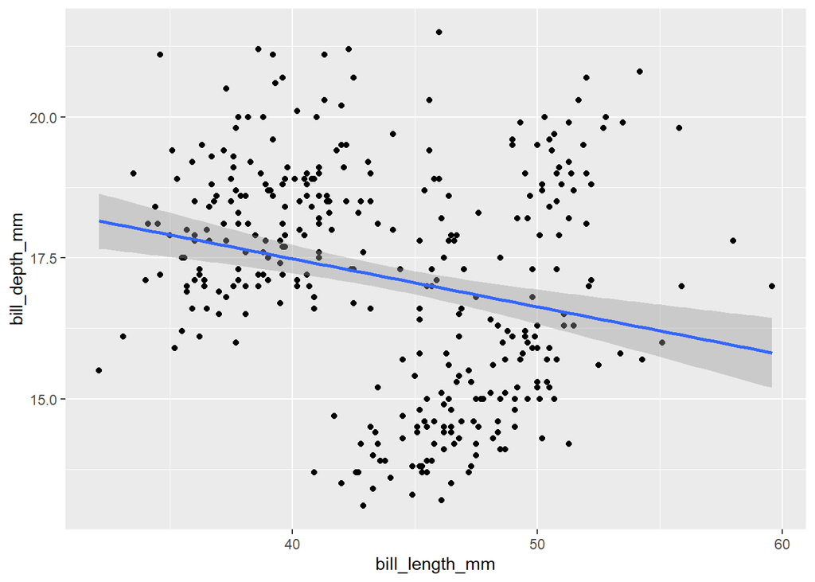

```r
ggplot(penguins, aes(x = bill_length_mm, y = bill_depth_mm)) +
  geom_point() +
  stat_smooth(method = "lm")
```

This runs a regression for us and plots the regression line and a shaded standard error. This indicates the amount of “wobble” in the line covers the 95% confidence interval. Our results show that bill length decreases with bill depth.

Do you think this is true?? Let’s test it…

#### Colour by a categorical variable.

A common action in R is to colour variables by a categorical or quantitative aspect of the data, in this case, `species`.

In this case, because species is defined in the dataset `penguins`, it is an aesthetic property of the data. Therefore, it has to be specified in `aes()`. We can add this using `col =` in the first line:

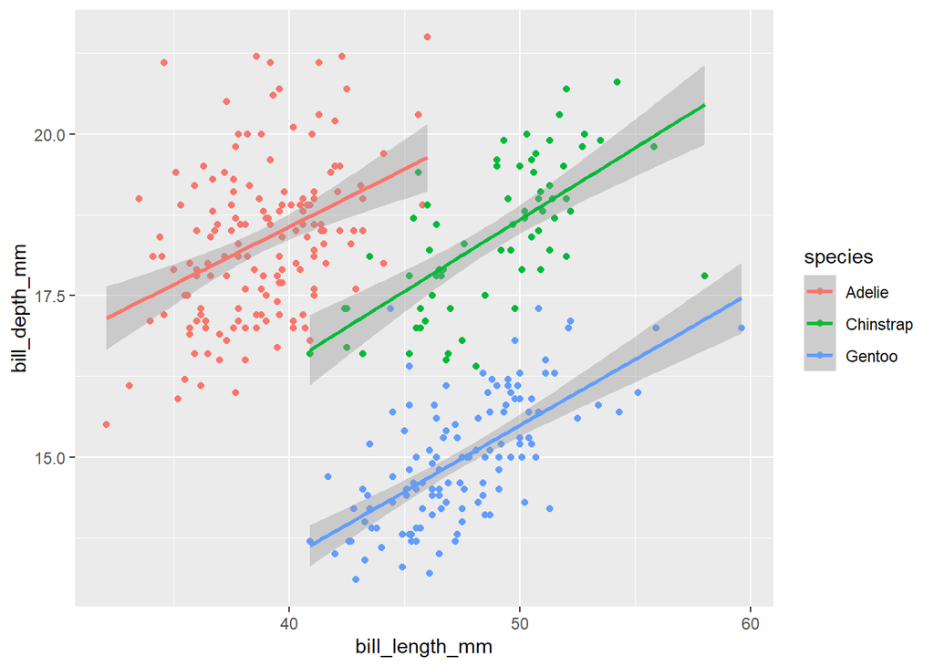

```r
ggplot(penguins, aes(x = bill_length_mm, y = bill_depth_mm, col = species)) +
  geom_point() +
  stat_smooth(method = "lm")
```

As you can see, the linear regressions are now grouped by their respective species. In this way, plotting our data showed us a new pattern that bill length and bill depth increase with each other within species. Thish highlights that you should ALWAYS EXPLORE AND PLOT YOUR DATA!

### Customisation

This graph looks good, but not amazing. We can now start to make modifications to improve the look of the graph.

#### Labels

We need to update the labels to something more meaningful. We can add this with `+ labs()`. Remember to put text in ” “!

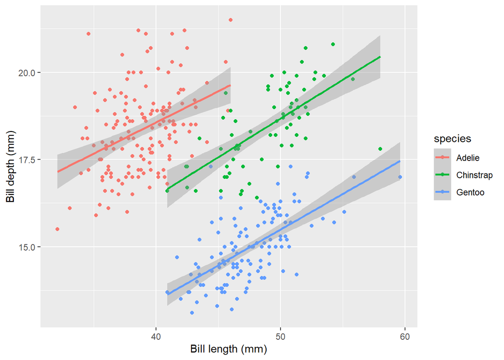

```r
ggplot(penguins, aes(x = bill_length_mm, y = bill_depth_mm, col = species)) +
  geom_point() +
  stat_smooth(method = "lm") +
  labs(x = "Bill length (mm)", y = "Bill depth (mm)")
```

#### Faceting

One nice feature of `ggplot2` is that you can facet your data based on a categorical variable. Let’s go back to a simple graph again, and add the line `facet_wrap()` specifying `species`:

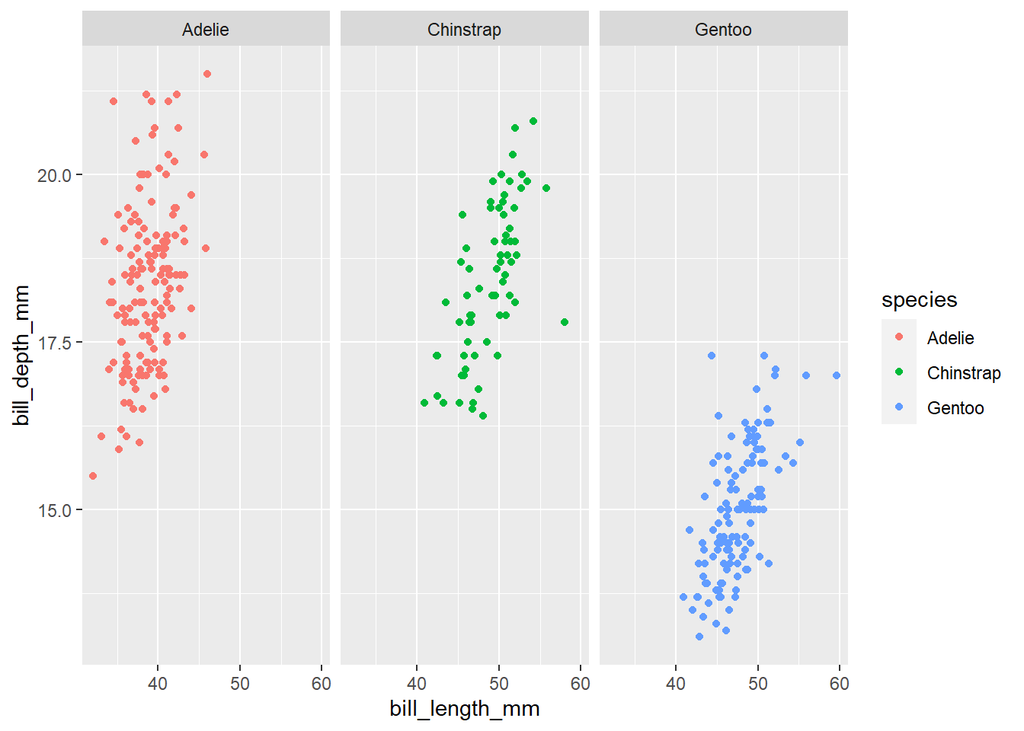

```r
ggplot(penguins, aes(x = bill_length_mm, y = bill_depth_mm, col = species)) +
  geom_point() +
  facet_wrap(~species)
```

### The finished graph

We can then combine the modifications we made above to make the full graph:

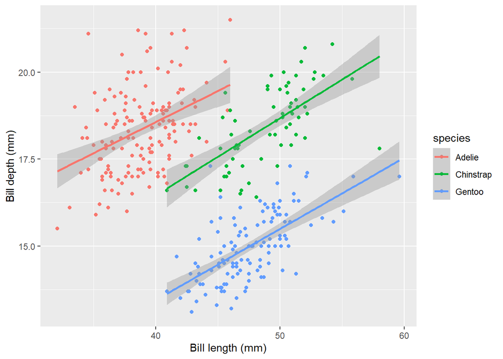

```r
ggplot(penguins, aes(x = bill_length_mm, y = bill_depth_mm, col = species)) +
  geom_point()+
  stat_smooth(method = "lm") +
  labs(x = "Bill length (mm)", y = "Bill depth (mm)")
```

```r
  facet_wrap(~species)
```

[output not shown]

### Troubleshooting:

- Did you forget a `+` ?
- Is `+` at the end of the line?
- Did you put text into inverted commas?
- Anything in `aes()` does not need inverted commas.
- Labels and colours need inverted commas.

### Saving a plot.

You’ve spent time making a nice plot - but how to save it? You can save by pointing and clicking in RStudio, but this becomes time consuming. A simpler way is to use `ggsave()`. This will save the most recently created plot. At the simplest level, you just specify a filename (`.png`, `.pdf`, `.jpg`):

```r
ggplot(penguins, aes(x = bill_length_mm, y = bill_depth_mm, col = species)) +
  geom_point()+
  stat_smooth(method = "lm") +
  labs(x = "Bill length (mm)", y = "Bill depth (mm)")
  facet_wrap(~species)

ggsave("figs/bill_morphology_plot.png")
```

This will automatically save with the dimensions that you have in your plot window. You can save with a fixed width and height as follows:

```r
ggsave("figs/bill_morphology_plot.png", width = 15, height = 10, units = "cm")
```

### Exercise 5.

1. Create a scatter-plot of bill depth against flipper length. Colour the points based on bill length. Can you change the colour range to go from red to purple by adding the line `scale_colour_gradient()`?

**Hint:** [click]**

Hint: use the tab key to look at the command options :)

2. Find a `geom_...()` to make a **histogram** of flipper_length_mm.

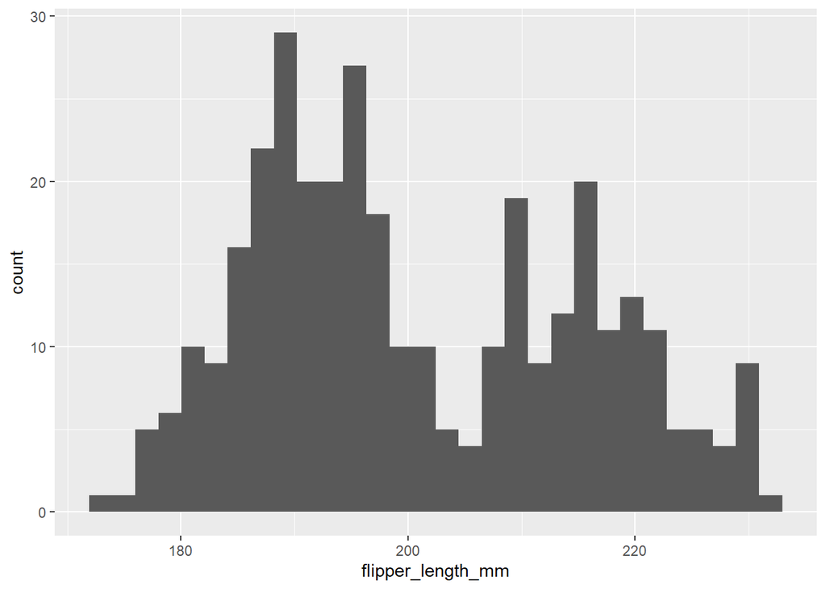

3. Find a `geom_...()` to make a **box-plot** of species (x-axis) and flipper_length_mm (y-axis).

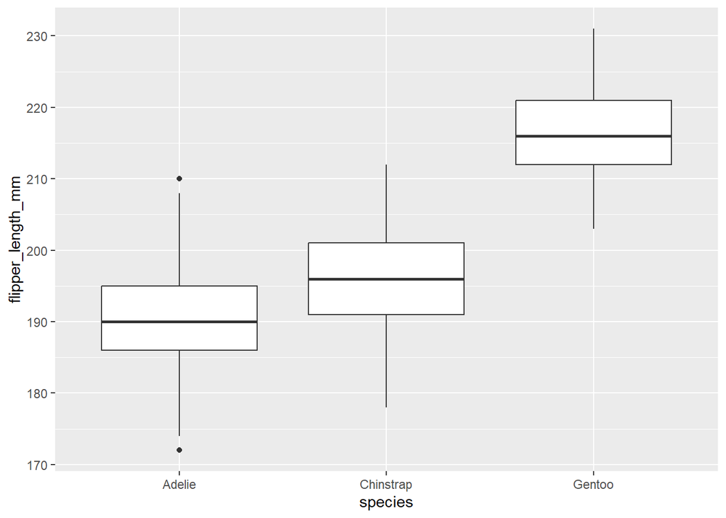

4. Colour the bars in the previous plot by `sex` (Hint: swap `col` for another command).

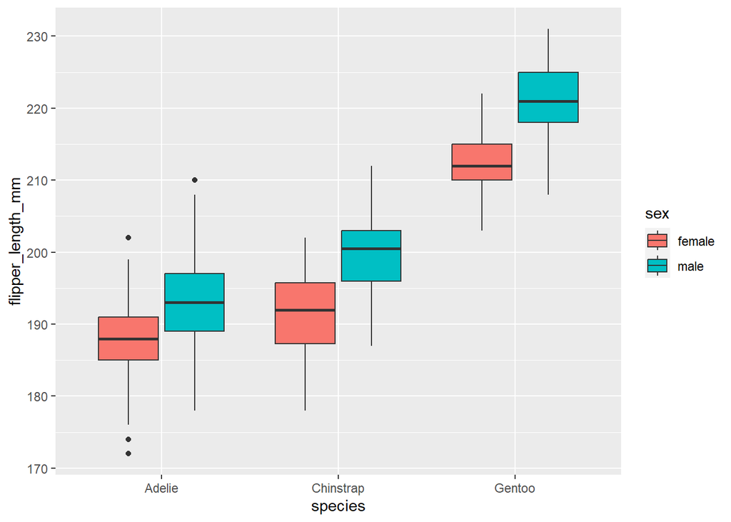

**Hint to remove NA’s:** [click]**

Hint: if you want to remove NA’s for sex, you can make a subset of the penguins dataset:

```
penguins_v2 <- filter(penguins, !is.na(sex))

ggplot(penguins_v2, aes(x = species, y = flipper_length_mm, fill = sex)) +
 geom_boxplot()
```

5. Use the tab key to explore the layer `theme_...()` and use it to make your graphs look nicer.

### Advanced exercises

6. Facet by species and change the axes so that the scales are not fixed on each facet (i.e. the scales are different and not the maxima of the entire plot area)? Hint - look at the specifications in `facet_wrap()`.

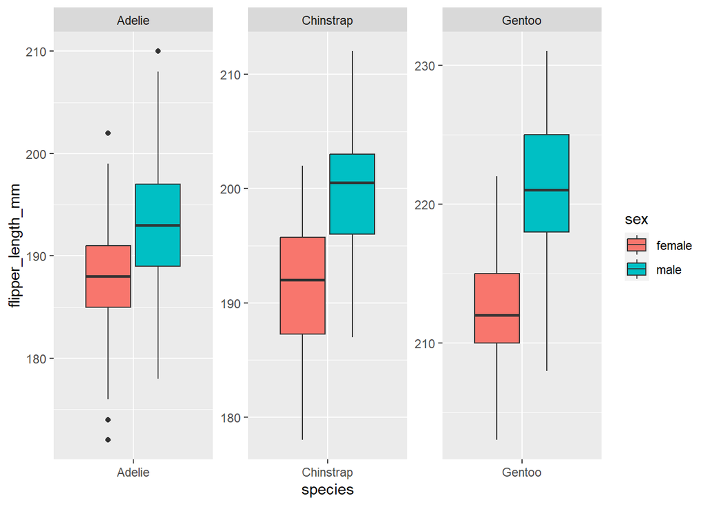

```r
ggplot(penguins_v2, aes(x = species, y = flipper_length_mm, fill = sex)) +
 geom_boxplot() +
 facet_wrap(~species, scales = "free")
```

7. Using `theme()`: … Orientate the x axis labels to 90 degrees. … Place the legend at the top of the graph, and/or remove it altogether. … Make the axis title size bigger. … Turn the plot background to be “lightblue”.